# ps4

Hannah Busshoff, Peter Heinemann

6 Mai 2018

## Part 1: Background

# 1

Birth weight is used as the primary measure for a baby’s health and welfare in economic research. Low birth weight is a direct target of health policy, due to the high correlation of LBW and costs. This study attempts to picture a more precise image of costs caused by LBW.

# 2

Birth weight is correlated with high blood pressure, cerebral palsy, deafness, blindness, asthma, lung disease, IQ, test scores, behavioral problems and cognitive development.

# 3

The correlation between health and LBW might not be causal but due to unobserved variables affecting both.

# 4

The twin approach helps to control for all characteristics of the mother. In the case of identical twins it controls for all genetic factors. Controling for this, the approach attemps to estimate correlation between twin differences in birth weight and twin differences in hospital charges, measures of health at birth, infant mortality.

# 5

The goal is to get an idea of the plausibility of the magnitudes of effects derived in the first part. They estimate the effect of maternal smoking during pregnancy on infant health outcomes. Probably overstated effects are established by attributing the entire effect of maternal smoking on infant health to the effect through LBW.

# 6

The treatment variable is maternal smoking during pregnancy. For observations, where this was absent, observed birth weight is the potential outcome for not being treated, while the potential outcome for being treated is not observed. Contrarily for ovservations where maternal smoking during pregnancy was present.

# 7

Potentially observations that differ in maternal smoking also differ in other covariates such that there are not enough comparable observations, for which causal effects of maternal smoking can be reliably estimated. There might be unobserved variables driving the correlation between birth weight and costs. Thus policy implications derived from analysis focusing on maternal smoking might thus reduce LBW but miss improving infant healtch and costs.

## Part 2: Empirics

```r
rm(list = ls())
getwd()
```

```
## [1] "C:/Users/Peter Heinemann/Google Drive/Peter_Heinemann/Master/2._Semester/Econometrics_Application/PS4"
```

```r
library(sandwich)
library(lmtest)
library(ggplot2)
library(easyGgplot2)
library(MatchIt)
library(MatchItSE)
library(tidyverse)
library(dplyr)
library(zeligverse)
```

# 1

```r
df = read.csv("ps4_birthweight.csv")
df_original = read.csv("ps4_birthweight.csv")
means = aggregate(df, list(df$mbsmoke), mean)
means
```

```
##   Group.1  bweight  mmarried      mhisp      fhisp    foreign    alcohol
## 1       0 3412.912 0.7514558 0.03626257 0.03785071 0.05982001 0.01879301
## 2       1 3137.660 0.4733796 0.02430556 0.03356481 0.02546296 0.09143519
##       mage     medu     fage    fedu nprenatal mbsmoke prenatal
## 1 26.81048 12.92986 27.84436 12.6739 10.962943       0 1.177607
## 2 25.16667 11.63889 24.74306 10.7037  9.862269       1 1.307870
```

# 2

```r
reg1 = lm(bweight ~ mbsmoke, data = df)
coeftest(reg1, vcov=vcovHC(reg1, type = "HC0"))
```

```
##
## t test of coefficients:
##
##              Estimate Std. Error t value  Pr(>|t|)
## (Intercept) 3412.9116     9.2835 367.634 < 2.2e-16 ***
## mbsmoke     -275.2519    21.2104 -12.977 < 2.2e-16 ***
## ---
## Signif. codes:  0 '***' 0.001 '**' 0.01 '*' 0.05 '.' 0.1 ' ' 1
```

Interpretation: On average birthweight of children whose mother smoked during pregnancy is 275 grams lower. This difference is highly statistically significant.

# 3

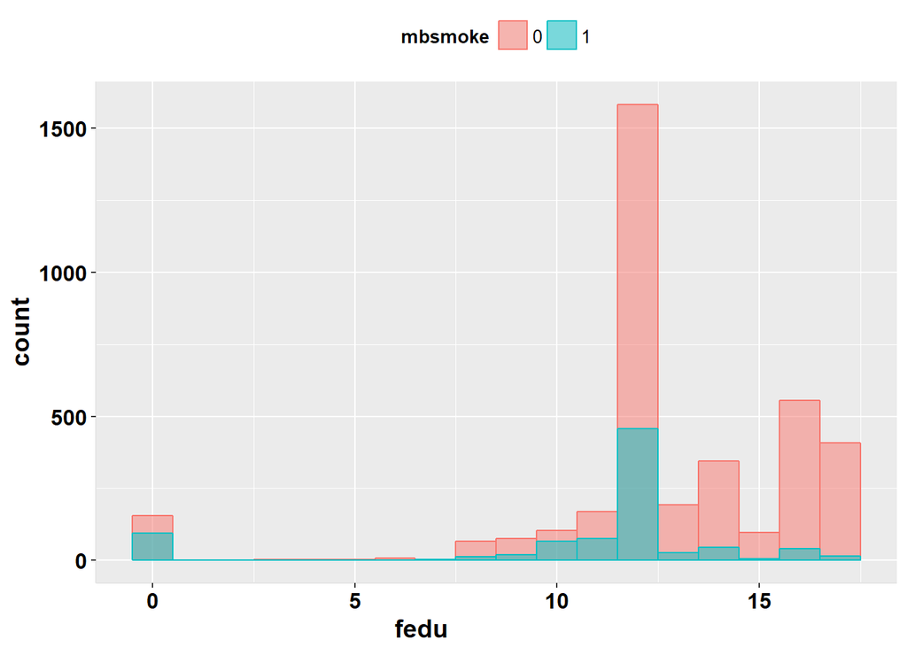

```r
ggplot2.histogram(data=df, xName='fedu',
        groupName='mbsmoke', legendPosition="top",
        alpha=0.5, binwidth = 1)
```

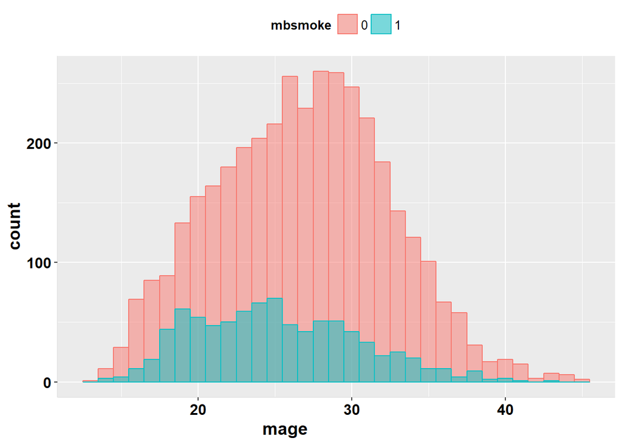

```r
ggplot2.histogram(data=df, xName = 'mage', groupName = 'mbsmoke', legendPosition="top",
                  alpha=0.5, binwidth=1)
```

We clearly see that the common support assumption is not violated.

# 4

```r
reg2 = lm(bweight ~ mbsmoke + ., data = df)
coeftest(reg2, vcov=vcovHC(reg2, type = "HC0"))
```

```
##
## t test of coefficients:
##
##               Estimate Std. Error t value  Pr(>|t|)
## (Intercept) 2779.93228   72.09002 38.5620 < 2.2e-16 ***
## mbsmoke     -207.39575   22.32036 -9.2918 < 2.2e-16 ***
## mmarried     126.82979   23.18841  5.4695 4.750e-08 ***
## mhisp         86.34095   52.57206  1.6423   0.10059
## fhisp        -14.90498   48.66764 -0.3063   0.75942
## foreign      -85.43047   39.79324 -2.1469   0.03186 *
## alcohol      -39.32979   45.24514 -0.8693   0.38475
## mage           2.93788    2.02190  1.4530   0.14628
## medu           0.67841    4.01522  0.1690   0.86584
## fage          -0.77462    1.17348 -0.6601   0.50922
## fedu           1.93114    3.25490  0.5933   0.55301
## nprenatal     32.17137    3.07830 10.4510 < 2.2e-16 ***
## prenatal      83.06520   18.18298  4.5683 5.045e-06 ***
## ---
## Signif. codes:  0 '***' 0.001 '**' 0.01 '*' 0.05 '.' 0.1 ' ' 1
```

The coefficient on smoking status now is slightly smaller in absolut terms and still highly significant.

# 5

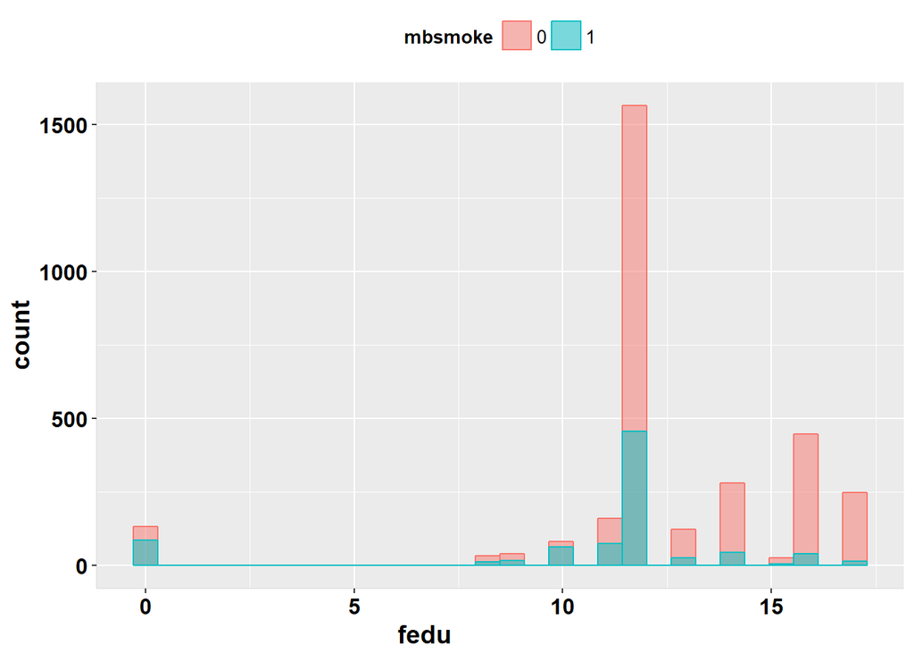

```r
df_match = matchit(mbsmoke ~ fedu + fage, data = df_original, method = "exact") %>% match.data()
ggplot2.histogram(data = df_match, xName = 'fedu', groupName = 'mbsmoke', legendPosition="top",
                  alpha=0.5, bindwidth=1)
```

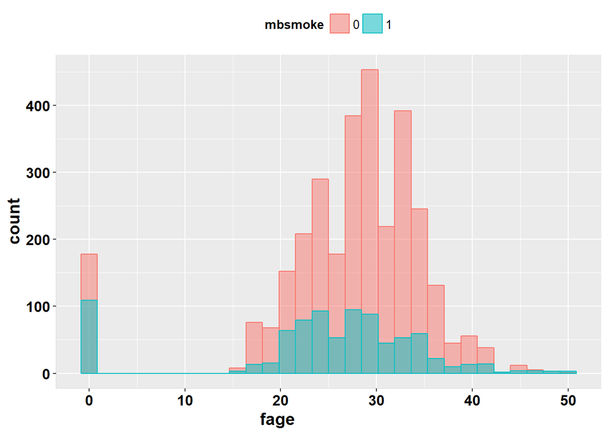

```r
ggplot2.histogram(data = df_match, xName = 'fage', groupName = 'mbsmoke', legendPosition="top",
                  alpha=0.5, bindwidth=1)
```

Distribution is slightly more balanced

# 6

```r
means_match = aggregate(df_match$bweight, list(df_match$mbsmoke), mean)
means_match[2,2]-means_match[1,2]
```

```
## [1] -274.9027
```

```r
reg3 = lm(bweight ~ mbsmoke, data = df_match)
coeftest(reg3, vcov=vcovHC(reg3, type = "HC0"))
```

```
##
## t test of coefficients:
##
##             Estimate Std. Error t value  Pr(>|t|)
## (Intercept) 3415.342     10.101 338.136 < 2.2e-16 ***
## mbsmoke     -274.903     21.851 -12.581 < 2.2e-16 ***
## ---
## Signif. codes:  0 '***' 0.001 '**' 0.01 '*' 0.05 '.' 0.1 ' ' 1
```

```r
att(matchit(mbsmoke ~ fedu + fage, data = df, method = "exact"), df_original$bweight)
```

```
## [1] -233.1914
```

# 7

```r
df$propscore = glm(mbsmoke ~.,data = df_original, family = "binomial") %>%
  predict(,type="response")
glm(mbsmoke ~., data = df_original, family = "binomial") %>% summary()
```

```
##
## Call:
## glm(formula = mbsmoke ~ ., family = "binomial", data = df_original)
##
## Deviance Residuals:
##     Min       1Q   Median       3Q      Max
## -1.9081  -0.6233  -0.4725  -0.3436   2.5836
##
## Coefficients:
##               Estimate Std. Error z value Pr(>|z|)
## (Intercept)  2.614e+00  3.542e-01   7.380 1.59e-13 ***
## bweight     -6.294e-04  6.981e-05  -9.016  < 2e-16 ***
## mmarried    -7.455e-01  9.929e-02  -7.508 6.01e-14 ***
## mhisp       -5.861e-01  3.465e-01  -1.692 0.090726 .
## fhisp       -1.570e-01  2.998e-01  -0.524 0.600406
## foreign     -9.885e-01  2.581e-01  -3.830 0.000128 ***
## alcohol      1.458e+00  1.857e-01   7.853 4.08e-15 ***
## mage         7.160e-03  9.054e-03   0.791 0.429065
## medu        -1.234e-01  1.972e-02  -6.258 3.90e-10 ***
## fage         4.779e-03  5.428e-03   0.880 0.378644
## fedu        -4.994e-02  1.344e-02  -3.717 0.000201 ***
## nprenatal    2.781e-03  1.138e-02   0.244 0.806927
## prenatal     1.645e-01  7.481e-02   2.198 0.027931 *
## ---
## Signif. codes:  0 '***' 0.001 '**' 0.01 '*' 0.05 '.' 0.1 ' ' 1
##
## (Dispersion parameter for binomial family taken to be 1)
##
##     Null deviance: 4461.5  on 4641  degrees of freedom
## Residual deviance: 3933.4  on 4629  degrees of freedom
## AIC: 3959.4
##
## Number of Fisher Scoring iterations: 5
```

# 8

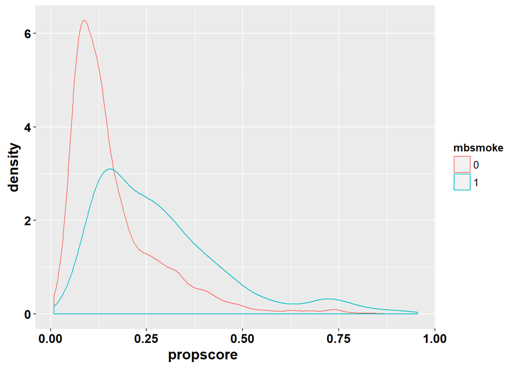

```r
ggplot2.density(data = df, xName = 'propscore', groupName = 'mbsmoke')
```

Why exclude observations with extreme propscores?